# Fit the normalised aggregated size spectrum and plot results

Andrew Edwards

Last rendered on 08 May, 2026

We demonstrate the normalised aggregated size spectrum here, as developed in [Quevedo et al. (2026)](https://www.sciencedirect.com/science/article/pii/S2351989426001769), which should be consulted for full details (see Appendix B). We first briefly show the main result from the paper, and then show code to build up a similar figure from simulated data to aid understanding. Users can replace the simulated data with their own data.

The idea is that we can fit size spectra to different components of the community, but it is inappropriate to fit a single size spectrum to the full community because of differences in sampling protocols between different species groups. For example, the sampling of zooplankton (e.g. using bongo nets) and pelagic fish (e.g. using a midwater trawl net) are quite different, and we cannot simply combine the data for a single size spectrum fit. In [Quevedo et al. (2026)](https://www.sciencedirect.com/science/article/pii/S2351989426001769) we had five different species groups; although the organisms were all sampled using bottom trawl gear, the catchability of the gear is expected to differ between species groups. So we fit each group separately and then derived and produced a combined normalised aggregated size spectrum. This was done for three different sampling scenarios or strata (a baseline, a no-take reserve that was protected from fishing, and fishing grounds), resulting in Figure 5 in the paper:

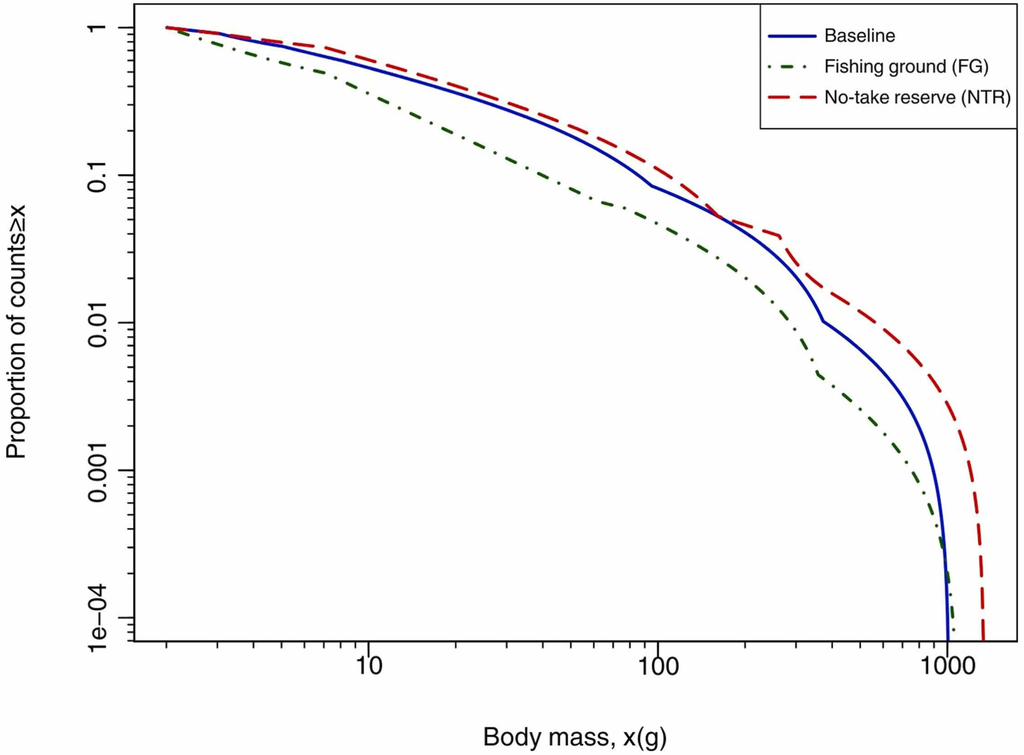

The curves are for bottom trawl surveys for three scenarios: Baseline conditions, and then four years later after implementation of a No-Take Reserve (Marine Protected Area) surveys were done both within the reserve (NTR) and outside in the fishing grounds (FG). The above plot is the normalised aggregated size spectrum for all three scenarios. This required developing aggregated size spectra that are then normalised to plot on the same axes. The figure shows individual body masses on the x-axis, with the proportion of organisms $\geq$ each body mass shown on the y-axis.

Key aspects are:

- the fits are not simple straight lines or curves, because they are aggregated
- the FG spectrum declines faster than the Baseline (note the logarithmic y-axis such that apparently minor graphical differences are actually quite large)
- the NTR spectrum declines more slowly (shallower) than the Baseline
- the appearance of large organisms showing up in the NTR.

Comparisons between scenarios have to be interpreted from the figure because there is no quantitative exponent that can be calculated from the aggregated size spectra.

Here we simulate some data to show the code needed to fit a normalised aggregated size spectrum (NASS). We first use individual body sizes, and then do the same for data that are only available in binned form.

## Generate simulated data

We first consider a single sampling scenario, and then later simulate fishing on larger organisms. We simulate $S = 4$ different species groups from different bounded power law (PLB) distributions. Using simulated data means that the fits should be much better than expected from real noisy data, but the point is to show how to use the code and to aid understanding (we had to do such an example to flesh out the ideas).

Each sample has a different sample size, assumed size spectrum exponent, and range of body sizes, prescribed as vectors:

```r
set.seed(42)

S <- 4

# For each sample, prescribe the sample size, exponent b, xmin and xmax.
n_vec <- c(6000, 6000, 1600, 2000)
b_vec_known <- c(-1.09, -2, -3, -4)
xmin_known <- c(0.3, 10, 100, 300)
xmax_known <- c(80, 4000, 1000, 1500)

res_list <- list()                      # To save results

for(s in 1:S){
  x_values <- rPLB(n_vec[s],            # Simulate values for sample s
                   b = b_vec_known[s],
                   xmin = xmin_known[s],
                   xmax = xmax_known[s])

  res_list[[s]] <- fit_size_spectrum(x_values)    # x_values get automatically saved
                                                  # as res_list[[s]]$x
}
  Warning in nlm(f = this_neg_ll_fn, p = p, ...): Inf replaced by maximum positive
  value

# Work out a global x-axis to use for the next plots:
xlim_global <- range(res_list[[1]]$x)
for(s in 2:S){
  xlim_global <- range(xlim_global,
                        range(res_list[[s]]$x))
}
xlim_global
  [1]    0.3003148 3882.4428352
```

Here are the four data sets with the four individually fit PLB distributions (the fits are good as data were simulated from PLB distributions):

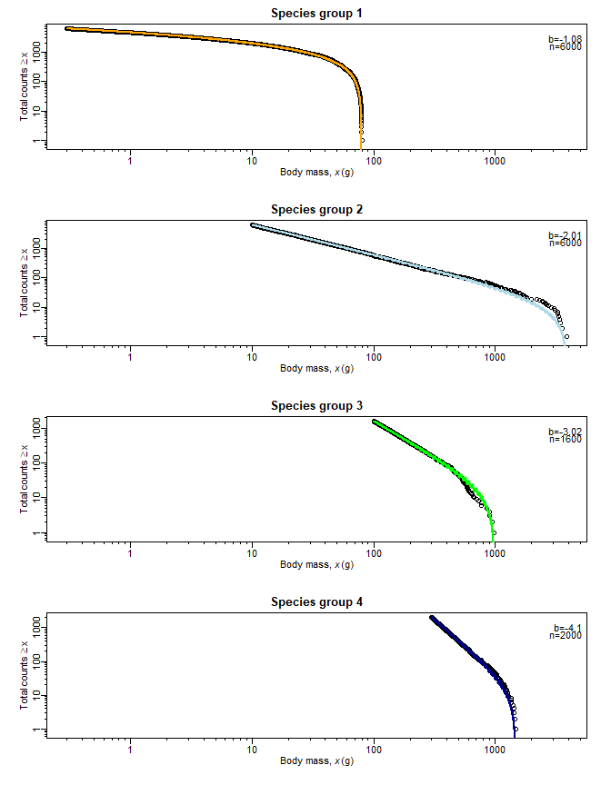

```r
# Use the first S of the default colours from plot_aggregate(), for consistency
#  with later plots:
col_vec <- eval(formals(plot_aggregate)$col_vec)[1:S]

# Refine plotting settings
par(mfrow = c(S, 1),
    mai = c(0.6, 0.5, 0.05, 0.3),
    mar = c(4.1, 4.1, 2.1, 2.1))
par_settings <- par(no.readonly = TRUE)           # to use for all plots

for(s in 1:S){
  plot(res_list[[s]],
       xlim = xlim_global,
       fit_col = col_vec[s],
       main = paste0("Species group ", s),
       legend_text_second_row_multiplier = 4)
}
```

The extra plotting arguments are to improved the plot, see `?plot.size_spectrum_numeric`, which is used because we have

```r
class(res_list[[s]])
  [1] "size_spectrum_numeric" "list"
```

### Aggregating distributions

So we have 4 fitted distributions that we want to aggregate, which we can do and plot with a single function:

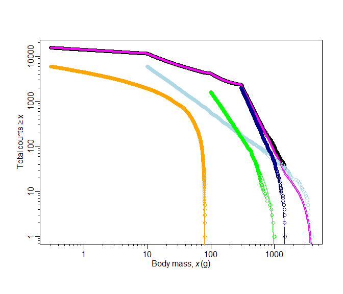

The four fitted PLB’s from above are shown on common axes using the same colour coding as above. Black circles are the full aggregated data set, and the thick magenta curve is the aggregated PLB distribution, the distribution obtained from aggregating the four fitted PLB’s together. The black circles are mostly hidden behind the magenta curve for low values of $x$, and at high values are overlaid by the light blue circles because those represent the only data for high $x$. The fits are very good because the data are simulated from PLB’s, and likelihood was used to estimated the $b$ exponents.

```r
orig_agg_fit <- plot_aggregate(res_list)
```

### Simulate disproportionate removal of larger individuals

To roughly simulate fishing, we take the above simulated data and disproportionately remove larger fish within each species group. We just remove 10% of the smallest half of the sizes, and 50% of the largest half, within each species group. This gives us the ‘fished’ scenario or strata (in the main text of the paper we used the term ‘sampling scenario’, but the raw data used ‘strata’ so this is what we use for the code and in Appendix B).

```r
res_fished_list <- list()
set.seed(42)                       # for reproducibility
for(s in 1:S){
  ind_sizes <- sort(res_list[[s]]$x)

  # Remove 10% of small fish and 50% of large within the group.
  num_sizes <- length(ind_sizes)        # Assume to be even
  indices_to_keep <- c(sample(1:(num_sizes/2),
                              size = 0.90 * num_sizes/2),
                       sample((num_sizes/2 +1):num_sizes,
                              size = 0.50 * num_sizes/2))
  x_values <- ind_sizes[indices_to_keep]

  res_fished_list[[s]] <- fit_size_spectrum(x_values)  # x_values get automatically saved
                                                       # as res_fished_list[[s]]$x
}
  Warning in nlm(f = this_neg_ll_fn, p = p, ...): Inf replaced by maximum positive
  value
```

Here are the four data sets with the four individually fit PLB distributions

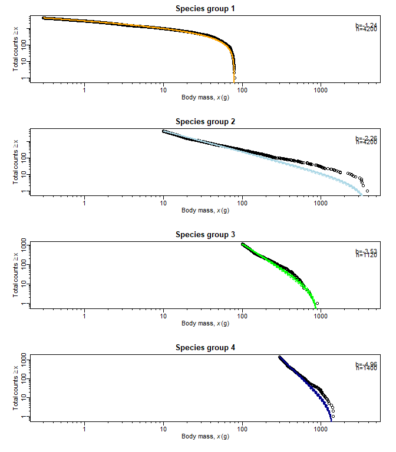

```r
par(par_settings)

for(s in 1:S){
  plot(res_fished_list[[s]],
       xlim = xlim_global,
       fit_col = col_vec[s],
       main = paste0("Species group ", s),
       legend_text_second_row_multiplier = 4)
}
```

And here is the normalised aggregated size spectrum in magenta:

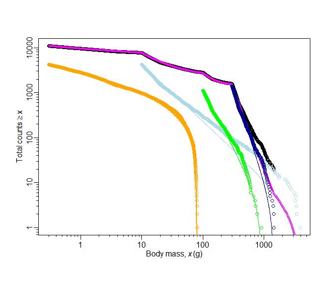

```r
fished_agg_fit <- plot_aggregate(res_fished_list)
```

To compare the original and the ‘fished’ normalised aggregated size spectra, first combine in a list.

```r
agg_list <- list(orig_agg_fit,
                 fished_agg_fit)
strata <- c("unfished",
            "fished")
```

We can then simply use the `plot_aggregate_fits()` function to plot the results for the two strata on the same graph, first without restriction to a common range of body masses or normalisation:

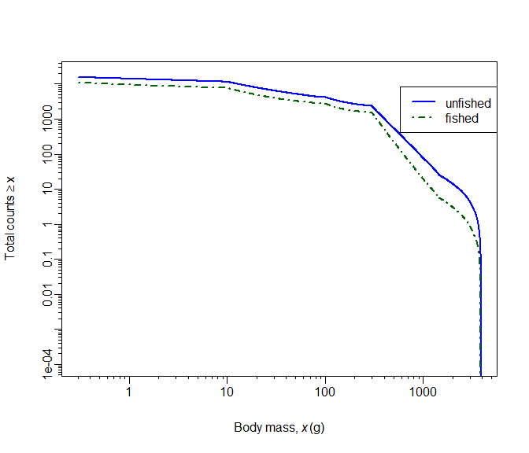

```r
plot_aggregate_fits(agg_list,
                    strata_names = strata,
                    ylim = c(10^(-4), 20000),
                    restrict = FALSE,
                    normalise = FALSE)
```

Both strata span the same range of body sizes (unlike for Figure B.22 in the paper). Since there is no simple size-spectrum exponent for such aggregated fits, and they have different $x_{min}$ values (at least in Figure B.22) and sample sizes, the fits are hard to compare.

Hence, we now restrict the fits to values above a common value (namely the maximum of the two aggregated $x_{min}$ values), and then normalise each aggregated fit by its resulting sample size, such that each starts at the same point (same body-mass on the x-axis and at 1 on the y-axis, which now represents the proportion (not number) of values above each body-mass). So with these options (the defaults are `restrict = TRUE` and `normalise = TRUE`) we have the normalised aggregated size spectra:

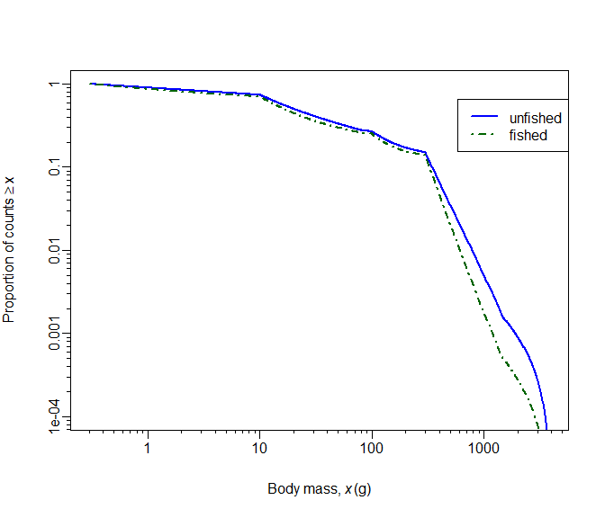

```r
plot_aggregate_fits(agg_list,
                    strata_names = strata,
                    ylim = c(10^(-4), 1))
```

Note that the y-axis is automatically labelled as the proportion of counts $\geq x$ rather than the total. This clearly shows a ‘steepening’ of the size spectrum for the fished scenario compared to the baseline – the counts are dropping off faster under the `fished’ scenario. Note the logarithmic y-axis, such that apparently minor differences are actually quite large. To further understanding, we also plot the same figure but with a linear y-axis:

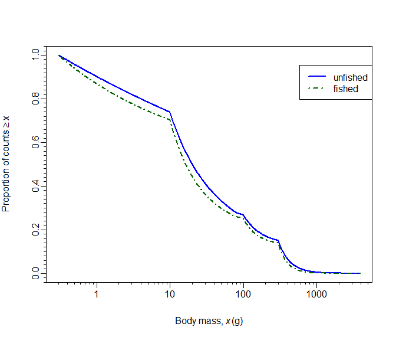

```r
plot_aggregate_fits(agg_list,
                    strata_names = strata,
                    log_axes = "x")
```

Again, this shows the fished strata size spectrum declining faster than that of the unfished strata. Note that both curves have to start at the same point, and reach 0 on the y-axis; minor changes that we see here are therefore indeed of importance (because the differences can only be so big).

### More extreme removal example

To further illustrate the NASS idea, we repeat the above simulation experiment but simply remove 50% of all individuals $\geq$ 100 g. The code is largely the same as above, with changes to the removal of individuals.

```r
res_fished_list_2 <- list()
set.seed(42)    # for reproducibility
for(s in 1:S){
  indiv_sizes <- sort(res_list[[s]]$x)

  # Remove 50% of any individuals > 100 g
  num_sizes <- length(indiv_sizes)
  indiv_sizes_over_100 <- indiv_sizes[indiv_sizes >= 100]

  x_values <- c(indiv_sizes[indiv_sizes < 100],
                sample(indiv_sizes_over_100,
                       size = floor(0.5 * length(indiv_sizes_over_100))))

  res_fished_list_2[[s]] <- fit_size_spectrum(x_values)
}
  Warning in nlm(f = this_neg_ll_fn, p = p, ...): Inf replaced by maximum positive
  value
```

Here are the four data sets with the four individually fit PLB distributions

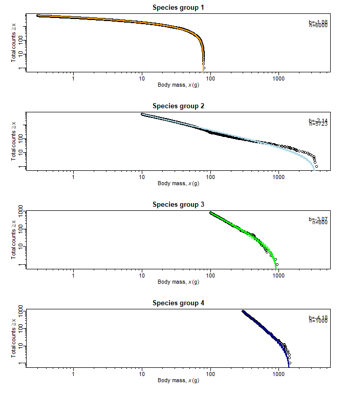

```r
par(par_settings)

for(s in 1:S){
  plot(res_fished_list_2[[s]],
       xlim = xlim_global,
       fit_col = col_vec[s],
       main = paste0("Species group ", s),
       legend_text_second_row_multiplier = 4)

}
```

And here is the normalised aggregated size spectrum in magenta:

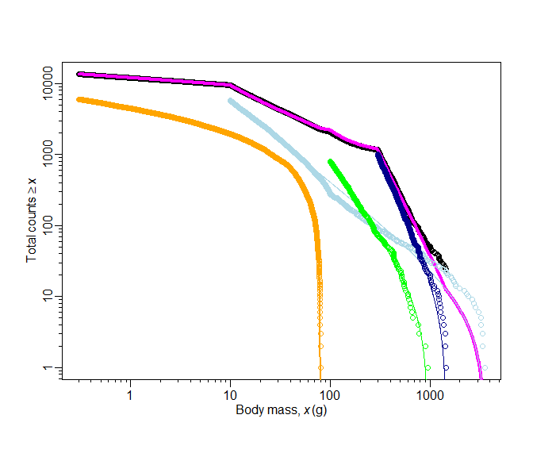

```r
fished_agg_fit_2 <- plot_aggregate(res_fished_list_2)
```

To compare the original and the ‘fished’ normalised aggregated size spectra, combine in a list.

```r
agg_list_2 <- list(orig_agg_fit,
                 fished_agg_fit_2)
```

The normalised aggregated size spectra is

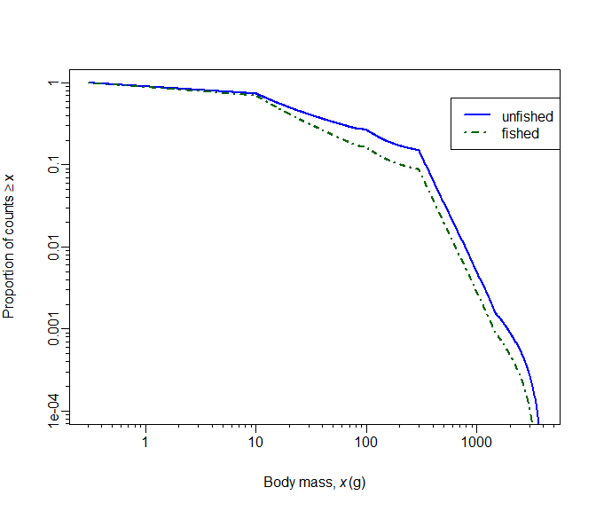

```r
plot_aggregate_fits(agg_list_2,
                    strata_names = strata,
                    ylim = c(10^(-4), 1))
```

showing the reduction due to fishing. And with a linear y-axis:

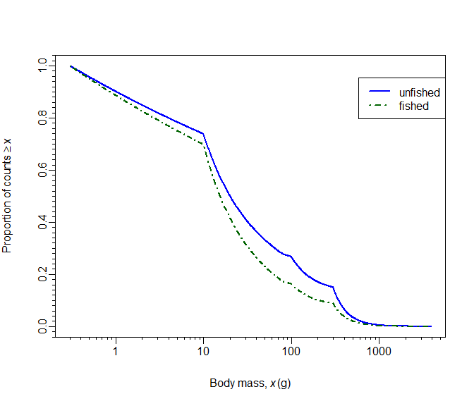

```r
plot_aggregate_fits(agg_list_2,
                    strata_names = strata,
                    log_axes = "x")
```

## Doing the above but for binned data

The same analyses can be done for data that are only available in binned form. See [Quevedo et al. (2026)](https://www.sciencedirect.com/science/article/pii/S2351989426001769) for examples using the MLEbins method, for which we have lengths that are converted to weights using species-specific length-weight relationships. For code from that analysis see [here](https://github.com/andrew-edwards/sizeSpectraFit/tree/main/report/mediterranean).

Here we simulate the same data as above and then bin it, to then fit using the MLEbin method and consequent plotting.

```r
set.seed(42)

res_mlebin_list <- list()                      # To save results

for(s in 1:S){
  x_values <- rPLB(n_vec[s],
                   b = b_vec_known[s],
                   xmin = xmin_known[s],
                   xmax = xmax_known[s])

  x_values_binned <- bin_data(x_values,
                              bin_width = 20)$bin_vals

  # Without this x_min would get set to zero, as detailed in error message in
  #  fit_size_spectrum_mlebin
  if(min(x_values_binned$bin_min) == 0){
    x_values_binned[which(x_values_binned$bin_min == 0), "bin_min"] <- 0.00001
  }

  res_mlebin_list[[s]] <- fit_size_spectrum(x_values_binned)
                 # binned data get included in res_mlebin_list[[s]]
}
  Warning in nlm(f = this_neg_ll_fn, p = p, ...): NA/NaN replaced by maximum positive
  value
  Warning in nlm(f = this_neg_ll_fn, p = p, ...): NA/NaN replaced by maximum positive
  value
  Warning in nlm(f = this_neg_ll_fn, p = p, ...): NA/NaN replaced by maximum positive
  value
  Warning in nlm(f = this_neg_ll_fn, p = p, ...): NA/NaN replaced by maximum positive
  value
  Warning in nlm(f = this_neg_ll_fn, p = p, ...): NA/NaN replaced by maximum positive
  value


# Plot each figure with same global x-axis:
xlim_global_mlebin <- c(min(res_mlebin_list[[1]]$data$bin_min),
                        max(res_mlebin_list[[1]]$data$bin_max))
for(s in 2:S){
  xlim_global_mlebin <- range(xlim_global_mlebin,
                              min(res_mlebin_list[[s]]$data$bin_min),
                              max(res_mlebin_list[[s]]$data$bin_max))
}
xlim_global_mlebin
  [1] 1.00e-05 3.89e+03
```

Here are the four data sets with the four individually fit PLB distributions as calculated using the MLEbin method:

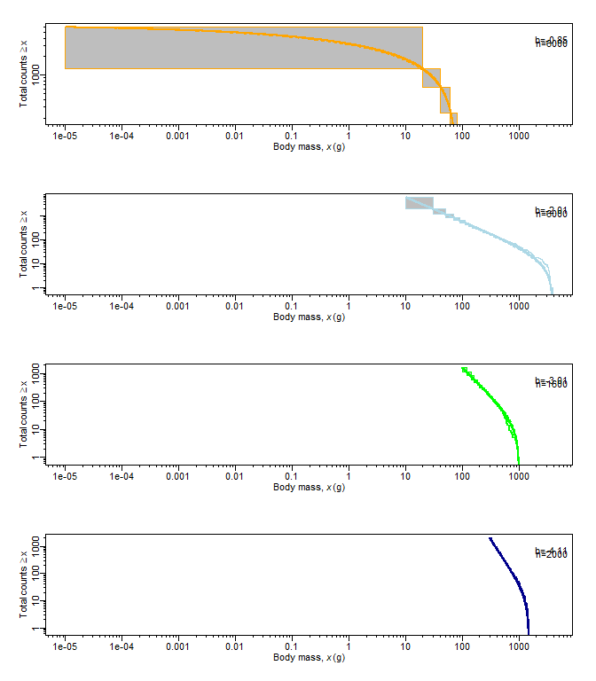

```r
par(par_settings)

for(s in 1:S){
  plot(res_mlebin_list[[s]],
       xlim = xlim_global_mlebin,
       fit_col = col_vec[s],
       rect_border_col = col_vec[s])
}
```

### Aggregating distributions

Aggregate as before:

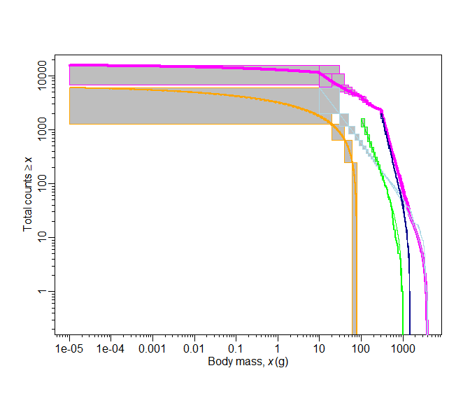

The four fitted PLB’s from above, calculated using the MLEbin method, are shown on the sames axes using the same colour coding as above. Magenta rectangles are for the full aggregated data set, and the thick magenta curve is the aggregated PLB distribution, the distribution obtained from aggregating the four fitted PLB’s together.

```r
orig_agg_fit_mlebin <- plot_aggregate_mlebin(res_mlebin_list)
```

### Simulate disproportionate removal of larger individuals

We repeat the above ‘More extreme removal example’ here, using the same idea (simply removing 50% of all individuals $\geq$ 100 g, based on `bin_min`), and then fitting using the MLEbin method:

```r
res_mlebin_fished_list <- list()
set.seed(42)    # for reproducibility
for(s in 1:S){
  # Just half the count for the fished sizes
  x_values_binned_fished <- res_mlebin_list[[s]]$data %>%
    dplyr::select(`bin_mid`:`bin_count`) %>%
    dplyr::mutate(bin_count = dplyr::if_else(bin_min >= 100,
                                             bin_count / 2,
                                             bin_count))

  res_mlebin_fished_list[[s]] <- fit_size_spectrum(x_values_binned_fished)
}
  Warning in nlm(f = this_neg_ll_fn, p = p, ...): NA/NaN replaced by maximum positive
  value
  Warning in nlm(f = this_neg_ll_fn, p = p, ...): NA/NaN replaced by maximum positive
  value
  Warning in nlm(f = this_neg_ll_fn, p = p, ...): NA/NaN replaced by maximum positive
  value
  Warning in nlm(f = this_neg_ll_fn, p = p, ...): NA/NaN replaced by maximum positive
  value
  Warning in nlm(f = this_neg_ll_fn, p = p, ...): NA/NaN replaced by maximum positive
  value
  Warning in nlm(f = this_neg_ll_fn, p = p, ...): NA/NaN replaced by maximum positive
  value
```

Here are the four data sets with the four individually fit PLB distributions

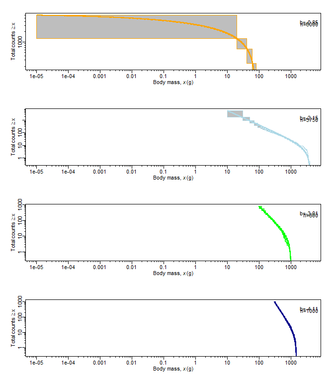

```r
par(par_settings)

for(s in 1:S){
  plot(res_mlebin_fished_list[[s]],
       xlim = xlim_global_mlebin,
       fit_col = col_vec[s],
       rect_border_col = col_vec[s])
}
```

And here is the normalised aggregated size spectrum in magenta:

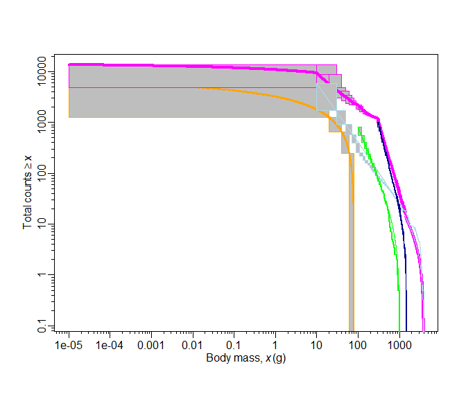

```r
fished_agg_fit_mlebin <- plot_aggregate_mlebin(res_mlebin_fished_list)
```

To compare the original and the `fished’ normalised aggregated size spectra, first combine in a list.

```r
agg_list_mlebin <- list(orig_agg_fit_mlebin,
                        fished_agg_fit_mlebin)
strata <- c("unfished",
            "fished")
```

We can then simply use the `plot_aggregate_fits()` function to plot the results for the two strata on the same graph:

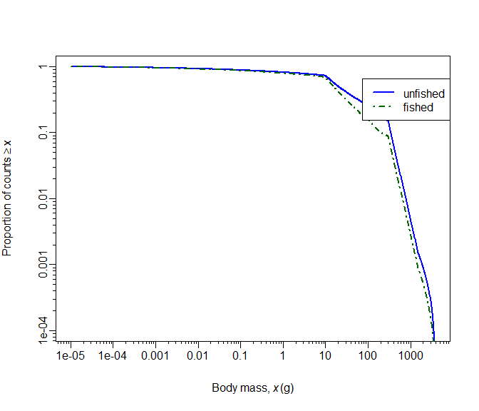

The two aggregated plots restricted to a common range of body masses and then normalised, to properly compare them.

```r
plot_aggregate_fits(agg_list_mlebin,
                    strata_names = strata,
                    ylim = c(10^(-4), 1))
```

And again with a linear y-axis:

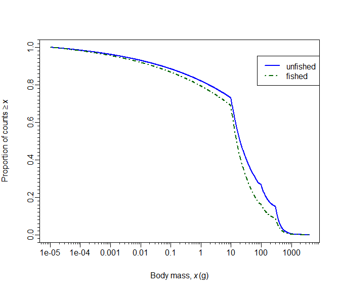

```r
plot_aggregate_fits(agg_list_mlebin,
                    strata_names = strata,
                    log_axes = "x")
```

Again, this shows the fished strata size spectrum declining faster than that of the unfished strata.

Quevedo, J., N. Bahamon, A.M. Edwards, M. Vigo, P. Couve, J. Aguzzi, J. Paramo, and J.B. Company (2026). No-take reserve improves size spectra and community structure of demersal megafauna in the Northwestern Mediterranean Sea. *Global Ecology and Conservation*. 68:e04227. https://www.sciencedirect.com/science/article/pii/S2351989426001769?via%3Dihub

## Session information

```r
sessionInfo()
  R version 4.5.1 (2025-06-13 ucrt)
  Platform: x86_64-w64-mingw32/x64
  Running under: Windows 11 x64 (build 22631)

  Matrix products: default
    LAPACK version 3.12.1

  locale:
  [1] LC_COLLATE=English_United States.utf8  LC_CTYPE=English_United States.utf8
  [3] LC_MONETARY=English_United States.utf8 LC_NUMERIC=C
  [5] LC_TIME=English_United States.utf8

  time zone: America/Vancouver
  tzcode source: internal

  attached base packages:
  [1] stats     graphics  grDevices utils     datasets  methods   base

  other attached packages:
  [1] sizeSpectraFit_0.0.99 testthat_3.2.3        devtools_2.4.5
  [4] usethis_3.2.1

  loaded via a namespace (and not attached):
   [1] tidyr_1.3.2       generics_0.1.4    sass_0.4.10       jpeg_0.1-11
   [5] digest_0.6.39     magrittr_2.0.4    evaluate_1.0.5    pkgload_1.4.1
   [9] fastmap_1.2.0     rprojroot_2.1.1   jsonlite_2.0.0    processx_3.8.6
  [13] pkgbuild_1.4.8    sessioninfo_1.2.3 brio_1.1.5        urlchecker_1.0.1
  [17] ps_1.9.1          promises_1.5.0    purrr_1.2.0       jquerylib_0.1.4
  [21] cli_3.6.5         shiny_1.12.1      rlang_1.1.6       ellipsis_0.3.2
  [25] withr_3.0.2       remotes_2.5.0     cachem_1.1.0      yaml_2.3.12
  [29] otel_0.2.0        tools_4.5.1       memoise_2.0.1     dplyr_1.1.4
  [33] httpuv_1.6.16     curl_7.0.0        vctrs_0.6.5       R6_2.6.1
  [37] mime_0.13         lifecycle_1.0.4   fs_1.6.6          htmlwidgets_1.6.4
  [41] miniUI_0.1.2      waldo_0.6.2       pkgconfig_2.0.3   desc_1.4.3
  [45] callr_3.7.6       pillar_1.11.1     bslib_0.9.0       later_1.4.4
  [49] glue_1.8.0        profvis_0.4.0     Rcpp_1.1.0        tidyselect_1.2.1
  [53] xfun_0.55         tibble_3.3.0      rstudioapi_0.17.1 knitr_1.51
  [57] xtable_1.8-4      htmltools_0.5.9   rmarkdown_2.30    compiler_4.5.1
```